Where the data was found : https://www1.nyc.gov/site/tlc/about/tlc-trip-record-data.page  
Documentation: yellow trips - https://www1.nyc.gov/assets/tlc/downloads/pdf/data_dictionary_trip_records_yellow.pdf

# New York taxis trips

This homework is about New York taxi trips. Here is something from [Todd Schneider](https://toddwschneider.com/posts/analyzing-1-1-billion-nyc-taxi-and-uber-trips-with-a-vengeance/):

> The New York City Taxi & Limousine Commission has released a detailed historical dataset covering over 1 billion individual taxi trips in the city from January 2009 through December 2019. Taken as a whole, the detailed trip-level data is more than just a vast list of taxi pickup and drop off coordinates: it's a story of a City. How bad is the rush hour traffic from Midtown to JFK? Where does the Bridge and Tunnel crowd hang out on Saturday nights? What time do investment bankers get to work? How has Uber changed the landscape for taxis? The dataset addresses all of these questions and many more.

The NY taxi trips dataset has been plowed by series of distinguished data scientists. The dataset is available from on Amazon S3 (Amazon's cloud storage service). The link for each file has the following form:

```
https://s3.amazonaws.com/nyc-tlc/trip+data/yellow_tripdata_{year}-{month}.csv
```

There is one CSV file for each NY taxi service (`yellow`, `green`, `fhv`) and each calendar month (replacing `{year}` and `{month}` by the desired ones). Each file is moderately large, a few gigabytes. The full dataset is relatively large if it has to be handled on a laptop (several hundred gigabytes).

You will focus on the `yellow` taxi service and a pair of months, from year 2015 and from year 2018. Between those two years, for hire vehicles services have taken off and carved a huge marketshare.

Whatever the framework you use, `CSV` files prove hard to handle. After downloading the appropriate files (this takes time, but this is routine), a first step will consist in converting the csv files into a more Spark friendly format such as `parquet`.

Saving into one of those formats require decisions about bucketing, partitioning and so on. Such decisions influence performance. It is your call. Many people have been working on this dataset, to cite but a few:

- [1 billion trips with a vengeance](https://toddwschneider.com/posts/analyzing-1-1-billion-nyc-taxi-and-uber-trips-with-a-vengeance/)
- [1 billion trips with R and SQL](http://freerangestats.info/blog/2019/12/22/nyc-taxis-sql)
- [1 billion trips with redshift](https://tech.marksblogg.com/billion-nyc-taxi-rides-redshift.html)
- [nyc-taxi](https://github.com/fmaletski/nyc-taxi-map)

Depending on your internet connection, **download the files** corresponding to **"yellow" taxis** for the years 2015 and 2018. Download **at least one month** (the same) for 2015 and 2018, if you can download all of them.

**Hint.** The 12 csv for 2015 are about 23GB in total, but the corresponding parquet file, if you can create it for all 12 months, is only about 3GB.

You **might** need the following stuff in order to work with GPS coordinates and to plot things easily.

```python
# !pip install plotly geojson geopandas geopy ipyleaflet
```

[output not shown]

For this homework **we will let you decide on the tools to use** (expected for Spark) and to **find out information all by yourself** (but don't hesitate to ask questions on the `slack` channel).

# Loading data as parquet files

We want to organize the data on a per year and per service basis. We want to end up with one `parquet` file for each year and each taxi service, since parquet is much better than CSV files.

**Hint.** Depending on your internet connection and your laptop, you can use only the "yellow" service and use one month of 2015 and 2018

CSV files can contain corrupted lines. You may have to work in order to perform ETL (Extract-Transform-Load) in order obtain a properly typed data frame.

You are invited to proceed as follows:

1. Try to read the CSV file without imposing a schema.
2. Inspect the inferred schema. Do you agree with Spark's typing decision?
3. Eventually correct the schema and read again the data
4. Save the data into parquet files
5. In the rest of your work, **you will only use the parquet files you created**, not the csv files (don't forget to choose a partitioning column and a number of partitions when creating the parquet files).

**Hint.** Don't forget to ask `Spark` to use all the memory and ressources from your computer.

**Hint.** Don't forget that you should specify a partitioning column and a number of partitions when creating the parquet files.

**Hint.** Note that the schemas of the 2015 and 2018 data are different...

**Hint.** When working on this, ask you and answer to the following questions:

1. What is the `StorageLevel` of the dataframe after reading the csv files?
2. What is the number of partitions of the dataframe?
3. Is it possible to tune this number at loading time?
4. Why would we want to modify the number of partitions when creating the parquet files?

**Reading the CSV files ; 2015-06 (June 2015) and 2018-06**

.storageLevel : **.storageLevel** , when applied to both dataframes after reading the csv's, returns StorageLevel(False, False, False, False, 1)

.rdd.getNumPartitions() : **.rdd.getNumPartitions()** , when applied to both dataframes after reading the csv's, returns 15 for the 2015 one, and 8 for the 2018 one

**spark.read.csv("...").rdd.partitionBy(...)** : allows us to tune the number of partitions at loading time --- **.repartition(numPartitions, *cols)** : allows us to tune the number of partitions of a dataframe (after loading)

```python
import os

import pandas as pd
import numpy as np
import matplotlib.pyplot as plt
import seaborn as sns

import plotly.express as px
import plotly.graph_objects as go # for interactive plots

import geopandas as gpd
import shapely

from pyspark import SparkConf
from pyspark.sql import SparkSession
from pyspark.sql import functions as fn
from pyspark.sql.types import StringType, IntegerType, FloatType, TimestampType, LongType

conf = SparkConf()
conf.set('spark.driver.memory', '8g')

spark = (SparkSession
         .builder
         .config(conf=conf)
         .appName("NYC Taxis")
         .getOrCreate()
)
```

```python
df1 = spark.read.options(header=True).csv("yellow_tripdata_2015-06.csv")
df2 = spark.read.options(header=True).csv("yellow_tripdata_2018-06.csv")
# The first line contains the column names for both csv's

dfs = [df1,df2]

for df in dfs: print(df.head(2),'\n')

df1.printSchema()
df2.printSchema()
```

```
[Row(VendorID='2', tpep_pickup_datetime='2015-06-02 11:19:29', tpep_dropoff_datetime='2015-06-02 11:47:52', passenger_count='1', trip_distance='1.63', pickup_longitude='-73.954429626464844', pickup_latitude='40.764141082763672', RateCodeID='1', store_and_fwd_flag='N', dropoff_longitude='-73.97475433…

[Row(VendorID='1', tpep_pickup_datetime='2018-06-01 00:15:40', tpep_dropoff_datetime='2018-06-01 00:16:46', passenger_count='1', trip_distance='.00', RatecodeID='1', store_and_fwd_flag='N', PULocationID='145', DOLocationID='145', payment_type='2', fare_amount='3', extra='0.5', mta_tax='0.5', tip_amo…

root
 |-- VendorID: string (nullable = true)
 |-- tpep_pickup_datetime: string (nullable = true)
 |-- tpep_dropoff_datetime: string (nullable = true)
 |-- passenger_count: string (nullable = true)
 |-- trip_distance: string (nullable = true)
 |-- pickup_longitude: string (nullable = true)
 |-- pickup_latitude: string (nullable = true)
 |-- RateCodeID: string (nullable = true)
 |-- store_and_fwd_flag: string (nullable = true)
 |-- dropoff_longitude: string (nullable = true)
 |-- dropoff_latitude: string (nullable = true)
 |-- payment_type: string (nullable = true)
 |-- fare_amount: string (nullable = true)
 |-- extra: string (nullable = true)
 |-- mta_tax: string (nullable = true)
 |-- tip_amount: string (nullable = true)
 |-- tolls_amount: string (nullable = true)
 |-- improvement_surcharge: string (nullable = true)
 |-- total_amount: string (nullable = true)

root
 |-- VendorID: string (nullable = true)
 |-- tpep_pickup_datetime: string (nullable = true)
 |-- tpep_dropoff_datetime: string (nullable = true)
 |-- passenger_count: string (nullable = true)
 |-- trip_distance: string (nullable = true)
 |-- RatecodeID: string (nullable = true)
 |-- store_and_fwd_flag: string (nullable = true)
 |-- PULocationID: string (nullable = true)
 |-- DOLocationID: string (nullable = true)
 |-- payment_type: string (nullable = true)
 |-- fare_amount: string (nullable = true)
 |-- extra: string (nullable = true)
 |-- mta_tax: string (nullable = true)
 |-- tip_amount: string (nullable = true)
 |-- tolls_amount: string (nullable = true)
 |-- improvement_surcharge: string (nullable = true)
 |-- total_amount: string (nullable = true)
```

```python
df2 = df2.withColumnRenamed('RatecodeID', 'RateCodeID')
```

##### Starting with the shared columns

```python
shared_columns = []

for c in df2.columns:
    if c in df1.columns: shared_columns.append(c)

[(_, shared_columns[_]) for _ in range(len(shared_columns))]
```

```
[(0, 'VendorID'),
 (1, 'tpep_pickup_datetime'),
 (2, 'tpep_dropoff_datetime'),
 (3, 'passenger_count'),
 (4, 'trip_distance'),
 (5, 'RateCodeID'),
 (6, 'store_and_fwd_flag'),
 (7, 'payment_type'),
 (8, 'fare_amount'),
 (9, 'extra'),
 (10, 'mta_tax'),
 (11, 'tip_amount'),
 (12, 'tolls_amount'),
 (13, 'improvement_surcharge'),
 (14, 'total_amount')]
```

```python
coltype_map = {
    shared_columns[0] : IntegerType(),
    shared_columns[1] : TimestampType(),
    shared_columns[2] : TimestampType(),
    shared_columns[3] : IntegerType(),
    shared_columns[4] : FloatType(),
    shared_columns[5] : IntegerType(),
    shared_columns[6] : StringType(),
    shared_columns[7] : IntegerType(),
    shared_columns[8] : FloatType(),
    shared_columns[9] : FloatType(),
    shared_columns[10] : FloatType(),
    shared_columns[11] : FloatType(),
    shared_columns[12] : FloatType(),
    shared_columns[13] : FloatType(),
    shared_columns[14]: FloatType()
}

for c in shared_columns:
    df1 = df1.withColumn(c, df1[c].cast(coltype_map[c]).alias(c))
    df2 = df2.withColumn(c, df2[c].cast(coltype_map[c]).alias(c))
```

##### Now with the personal columns

```python
df1.drop(*shared_columns).printSchema()
df2.drop(*shared_columns).printSchema()
```

```
root
 |-- pickup_longitude: string (nullable = true)
 |-- pickup_latitude: string (nullable = true)
 |-- dropoff_longitude: string (nullable = true)
 |-- dropoff_latitude: string (nullable = true)

root
 |-- PULocationID: string (nullable = true)
 |-- DOLocationID: string (nullable = true)
```

```python
df1 = (df1.withColumn('pickup_longitude', df1.pickup_longitude.cast(FloatType()))
 .withColumn('pickup_latitude', df1.pickup_latitude.cast(FloatType()))
 .withColumn('dropoff_longitude', df1.dropoff_longitude.cast(FloatType()))
 .withColumn('dropoff_latitude', df1.dropoff_latitude.cast(FloatType()))
)

df2 = (df2.withColumn('PULocationID', df2.PULocationID.cast(IntegerType()))
 .withColumn('DOLocationID', df2.DOLocationID.cast(IntegerType()))
)
```

```python
df1 = df1.withColumn('weekday', fn.date_format(df1.tpep_pickup_datetime, 'E'))
df2 = df2.withColumn('weekday', fn.date_format(df2.tpep_pickup_datetime, 'E'))

df1 = df1.withColumn('hour', fn.date_format(df1.tpep_pickup_datetime, 'H'))
df2 = df2.withColumn('hour', fn.date_format(df2.tpep_pickup_datetime, 'H'))
```

##### Creating the parquet files (balance the amount of data mapped across the cluster)

```python
if os.path.exists("parquet_2015") & os.path.exists("parquet_2018"):
    print("parquet files already existing")

else:
    if not os.path.exists("parquet_2015"):
        df1.repartition("weekday", "hour").write.partitionBy("weekday", "hour").parquet("parquet_2015")
    if not os.path.exists("parquet_2018"):
        df2.repartition("weekday", "hour").write.partitionBy("weekday", "hour").parquet("parquet_2018")
```

# Investigate (at least) one month of data in 2015

From now on, you will be using **the parquet files you created for 2015**.

We shall visualize several features of taxi traffic during one calendar month in 2015 and the same calendar month in 2018.

**Hint.** In order to build appealing graphics, you may stick to `matplotlib + seaborn`, you can use also `plotly`, which is used a lot to build interactive graphics, but you can use whatever you want.

The following longitudes and lattitudes encompass Newark and JFK airports, Midtown North and Verazzano bridge.

```python
long_min = -74.10
long_max = -73.70
lat_min = 40.58
lat_max = 40.90
```

1. Using these boundaries, **filter the 2015 data** (using pickup and dropoff longitude and latitude) and count the number of trips for each value of `passenger_count` and make a plot of that.

```python
if os.path.exists("boundaries2015"):
    print("'boundaries2015' parquet file already exists")

else:
    df1 = spark.read.parquet("parquet_2015")
    df1.filter((df1['pickup_longitude'].between(long_min,long_max))\
               &(df1['pickup_latitude'].between(lat_min,lat_max))\
               &(df1['dropoff_longitude'].between(long_min,long_max))\
               &(df1['dropoff_latitude'].between(lat_min,lat_max)))\
    .repartition("weekday", "hour").write.partitionBy("weekday", "hour").parquet("boundaries2015")

    print("'boundaries2015' parquet file created")
```

```
'boundaries2015' parquet file already exists
```

```python
boundaries2015 = spark.read.parquet("boundaries2015")
```

```python
tripsPerPassengerCount = (boundaries2015
                          .groupBy('passenger_count')
                          .agg(fn.count('VendorID').alias('n_trips')) # we could've counted on any feature
                         ).toPandas()

tripsPerPassengerCount.sort_values('passenger_count').reset_index(drop=True)
```

|  | passenger_count | n_trips |
| --- | --- | --- |
| 0 | 0 | 1406 |
| 1 | 1 | 8517735 |
| 2 | 2 | 1714304 |
| 3 | 3 | 514124 |
| 4 | 4 | 243582 |
| 5 | 5 | 667755 |
| 6 | 6 | 427582 |
| 7 | 7 | 18 |
| 8 | 8 | 3 |
| 9 | 9 | 14 |

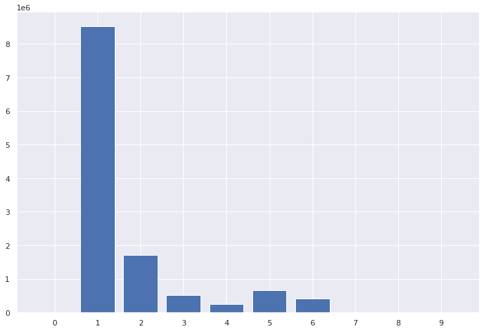

```python
def plotly_hist():
    fig = go.Figure(
        go.Bar(
        x = tripsPerPassengerCount.passenger_count,
        y = tripsPerPassengerCount.n_trips
        ))

    fig.update_layout(
        xaxis = dict(
            tickmode = 'linear',
            tick0 = 0.0,
            dtick = 1
        ),
        title="Number of trips (with boundaries as shown above) per passenger_count",
        xaxis_title="passenger_count",
        yaxis_title="n_trips",
    )
    return fig

def plt_hist():
    return plt.bar(tripsPerPassengerCount.passenger_count, tripsPerPassengerCount.n_trips)

plt.figure(figsize=(12,8))
sns.set_theme()
plt_hist(); # plotly_hist() on our end does not show the figure when we re-open the notebook
plt.xticks(range(0,10));
```

- What's special with trips with zero passengers?
- What's special with trips with more than $6$ passengers?

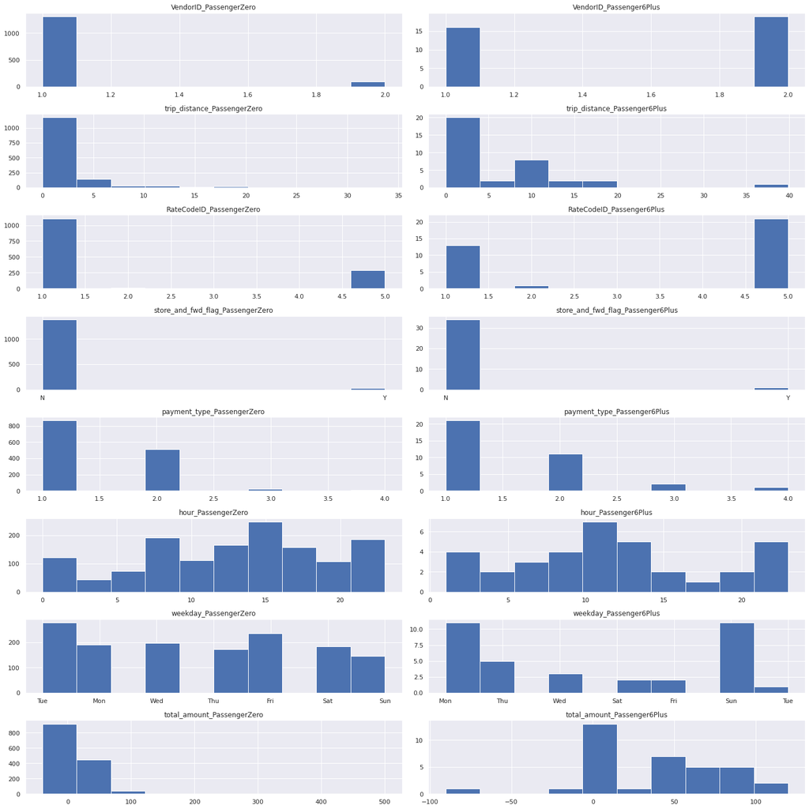

```python
PassengerZero = boundaries2015.where(boundaries2015.passenger_count == 0).toPandas()
Passenger6Plus = boundaries2015.where(boundaries2015.passenger_count > 6).toPandas()

sns.set_theme()
to_explore = [0,4,7,8,11,-1,-2,-3]
plt.figure(figsize=(20,20))

l_passengers = [PassengerZero,Passenger6Plus]; _ = 1

for c in to_explore:
    for p in l_passengers:
        plt.subplot(8,2,_)
        plt.hist(p[p.columns[c]])
        plt.title(f"{p.columns[c]}_{['PassengerZero','Passenger6Plus'][(_-1)%2]}")
        plt.tight_layout()
        _+=1
```

- What is the largest distance travelled during this month? Is it the first taxi on the moon?
- Plot the distribution of the `trip_distance` (using an histogram for instance) during year 2015. Focus on trips with non-zero trip distance and trip distance less than 30 miles.

```python
max_dist = boundaries2015.select('trip_distance').agg(fn.max('trip_distance')).collect()[0][0]
print(f"The largest distance travelled during this month is {max_dist} miles")
```

```
The largest distance travelled during this month is 10083318.0 miles
```

```python
trip_distances1 = (boundaries2015
                  .where
                   (
                       (boundaries2015.trip_distance > 0)
                       &(boundaries2015.trip_distance <= 1.8)
                   )
                  .select('trip_distance')
                  .toPandas()
                 )

trip_distances2 = (boundaries2015
                  .where
                   (
                      (boundaries2015.trip_distance > 1.8)
                      &(boundaries2015.trip_distance < 30)
                   )
                  .select('trip_distance')
                  .toPandas()
                 )

# otherwise returns an error if all-in-one approach, don't know why. But no big deal
```

[figure not shown]

```python
plt.figure(figsize=(12,8))
plt.hist(np.vstack((trip_distances1,trip_distances2)), range=(0,25));
plt.title('trip_distance distribution');
```

Let's look at what Spark does for these computations

1. Use the `explain` method or have a look at the [Spark UI](http://localhost:4040/SQL/) to analyze the job. You should be able to assess
   - Parsed Logical Plan
   - Analyzed Logical Plan
   - Optimized Logical Plan
   - Physical Plan
2. Do the Analyzed Logical Plan and Optimized Logical Plan differ? Spot the differences if any. How would a RDBMS proceed with such a query?
3. How does the physical plan differ from the Optimized Logical Plan? What are the keywords you would not expects in a RDBMS? What is their meaning?
4. Inspect the stages on [Spark UI](http://localhost:4040/stages/stage). How many *stages* are necessary to complete the Spark job? What are the roles of `HashAggregate` and `Exchange hashpartitioning`?
5. Does the physical plan perform `shuffle` operations? If yes how many?
6. What are tasks with respect to stages (in Spark language)? How many tasks are your stages made of?

Now, compute the following and produce relevant plots:

1. Break down the trip distance distribution for each day of week
2. Count the number of distinct pickup location
3. Compute and display tips and profits as a function of the pickup location

[figure not shown]

```python
import calendar

plt.figure(figsize=(12,10))
_ = 1

for wday in list(calendar.day_abbr):
    plt.subplot(4,2,_)
    plt.hist(boundaries2015.where(boundaries2015.weekday == wday).select('trip_distance').toPandas(), range=(0,25))
    # we want to avoid extreme outliers (such as max_dist) so we set a range of values
    plt.title(f'trip_distance distribution ({wday})')
    plt.tight_layout()
    _+=1
```

```python
locations = gpd.read_file("locid_sf.zip").to_crs(epsg=4326)

def zone2015(long, lat):
    long_lat = (long, lat)
    point = shapely.geometry.Point(long_lat)

    zone = locations[locations.geometry.intersects(point)].zone.values
    return zone[0] if zone.size != 0  else "not_found"

def borough2015(long, lat):
    long_lat = (long, lat)
    point = shapely.geometry.Point(long_lat)

    borough = locations[locations.geometry.intersects(point)].borough.values
    return borough[0] if borough.size != 0  else "not_found"

zone2015_udf = fn.udf(zone2015, StringType())
borough2015_udf = fn.udf(borough2015, StringType())
```

```python
boundaries2015 = boundaries2015.withColumn("zone", zone2015_udf(fn.col('pickup_longitude'), fn.col('pickup_latitude')))
boundaries2015 = boundaries2015.withColumn("borough", borough2015_udf(fn.col('pickup_longitude'), fn.col('pickup_latitude')))
```

Unfortunately, even after hours, we cant get the zone and borough calculations to end when applied to boundaries2015.  
The UDF takes wayyyyyy too much time to finish.  
While not satisfying, we limit ourselves to 10000 rows to at least have a result in front of us. It doesn't change anything to our queries, but of course the plots will be less significant

```python
limit10K = boundaries2015.limit(10000)
limit10K = limit10K.withColumn('profit',
                              fn.round(
                                  fn.col('total_amount')
                                  -fn.col('mta_tax')
                                  -fn.col('tolls_amount'),2))
tip_profit = limit10K.select('borough','tip_amount','profit')\
.groupBy('borough').agg(fn.sum('profit'),fn.sum('tip_amount')).toPandas()
```

```python
tip_profit
```

|  | borough | sum(profit) | sum(tip_amount) |
| --- | --- | --- | --- |
| 0 | Manhattan | 128266.619985 | 16098.569991 |
| 1 | Queens | 16091.229867 | 1940.330004 |
| 2 | Brooklyn | 2813.589988 | 336.090001 |
| 3 | not_found | 182.230003 | 19.310000 |
| 4 | Bronx | 76.599999 | 5.000000 |

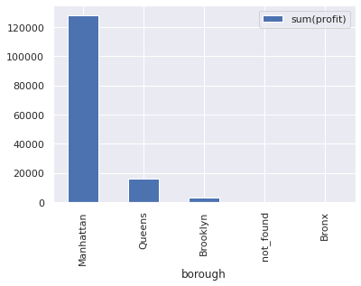

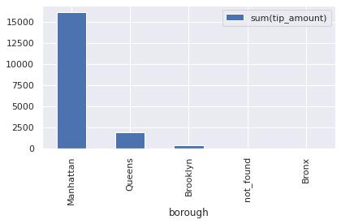

```python
tip_profit.plot.bar('borough',tip_profit.columns[1]);
tip_profit.plot.bar('borough',tip_profit.columns[2]);
plt.tight_layout();
```

# Investigate one month of trips data in 2015 and 2018

Consider one month of trips data from `yellow` taxis for each year

1. Filter and cache/persist the result

## Assessing seasonalities and looking at time series

Compute and plot the following time series indexed by day of the week and hour of day:

1. The number of pickups
2. The average fare
3. The average trip duration
4. Plot the average of ongoing trips

```python
df2015 = spark.read.parquet("parquet_2015")
df2018 = spark.read.parquet("parquet_2018")

#Adding trip_duration columns
df2015 = df2015.withColumn('trip_duration',
                   fn.round(
                       (fn.col('tpep_dropoff_datetime').cast(LongType())
                        -fn.col('tpep_pickup_datetime').cast(LongType())
                       )/60,2))

df2018 = df2018.withColumn('trip_duration',
                   fn.round(
                       (fn.col('tpep_dropoff_datetime').cast(LongType())
                        -fn.col('tpep_pickup_datetime').cast(LongType())
                       )/60,2))
```

##### Number of pickups

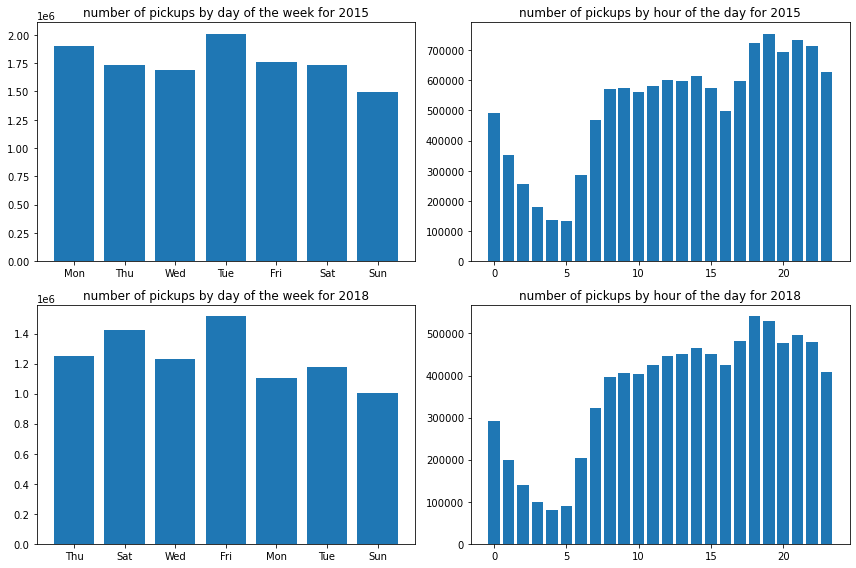

```python
plt.figure(figsize=(12,8))

n_PU_wd_2015 = df2015.groupBy('weekday').agg(fn.count('pickup_longitude').alias('n_PU')).toPandas()
n_PU_hour_2015 = df2015.groupBy('hour').agg(fn.count('pickup_longitude').alias('n_PU')).toPandas()

plt.subplot(2,2,1)
plt.bar(n_PU_wd_2015.weekday,n_PU_wd_2015.n_PU)
plt.title('number of pickups by day of the week for 2015');

plt.subplot(2,2,2)
plt.bar(n_PU_hour_2015.hour,n_PU_hour_2015.n_PU)
plt.title('number of pickups by hour of the day for 2015');

###

n_PU_wd_2018 = df2018.groupBy('weekday').agg(fn.count('PULocationID').alias('n_PU')).toPandas()
n_PU_hour_2018 = df2018.groupBy('hour').agg(fn.count('PULocationID').alias('n_PU')).toPandas()

plt.subplot(2,2,3)
plt.bar(n_PU_wd_2018.weekday,n_PU_wd_2018.n_PU)
plt.title('number of pickups by day of the week for 2018');

plt.subplot(2,2,4)
plt.bar(n_PU_hour_2018.hour,n_PU_hour_2018.n_PU)
plt.title('number of pickups by hour of the day for 2018');

plt.tight_layout();
```

##### Average fare

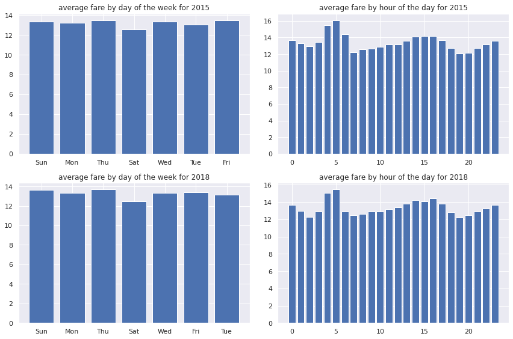

```python
plt.figure(figsize=(12,8))

avg_fare_wd_2015 = df2015.groupBy('weekday').agg(fn.mean('fare_amount').alias('avg_fare')).toPandas()
avg_fare_hour_2015 = df2015.groupBy('hour').agg(fn.mean('fare_amount').alias('avg_fare')).toPandas()

plt.subplot(2,2,1)
plt.bar(avg_fare_wd_2015.weekday,avg_fare_wd_2015.avg_fare)
plt.title('average fare by day of the week for 2015');

plt.subplot(2,2,2)
plt.bar(avg_fare_hour_2015.hour,avg_fare_hour_2015.avg_fare)
plt.title('average fare by hour of the day for 2015');

###

avg_fare_wd_2018 = df2018.groupBy('weekday').agg(fn.mean('fare_amount').alias('avg_fare')).toPandas()
avg_fare_hour_2018 = df2018.groupBy('hour').agg(fn.mean('fare_amount').alias('avg_fare')).toPandas()

plt.subplot(2,2,3)
plt.bar(avg_fare_wd_2018.weekday,avg_fare_wd_2018.avg_fare)
plt.title('average fare by day of the week for 2018');

plt.subplot(2,2,4)
plt.bar(avg_fare_hour_2018.hour,avg_fare_hour_2018.avg_fare)
plt.title('average fare by hour of the day for 2018');

plt.tight_layout();
```

##### Average trip duration (in minutes)

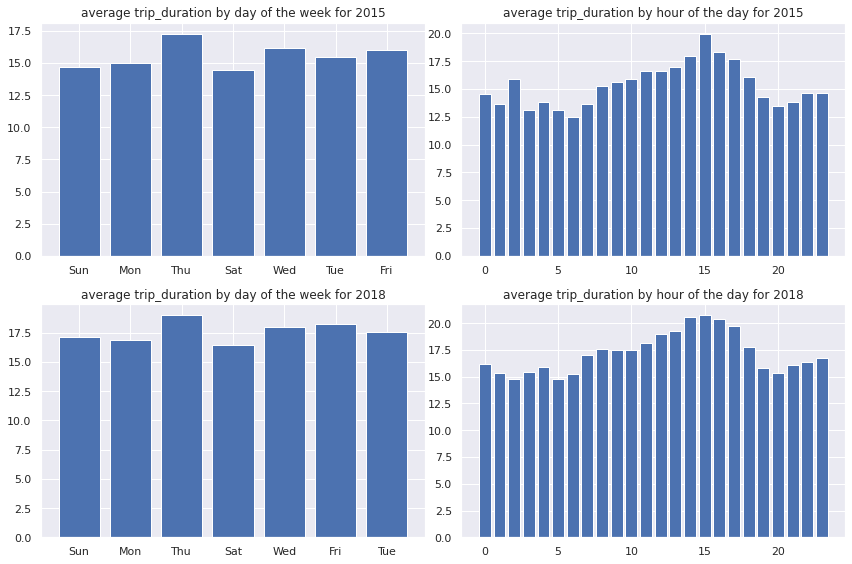

```python
plt.figure(figsize=(12,8))

avg_trip_duration_wd_2015 = df2015.groupBy('weekday').agg(fn.mean('trip_duration').alias('avg_trip_duration')).toPandas()
avg_trip_duration_hour_2015 = df2015.groupBy('hour').agg(fn.mean('trip_duration').alias('avg_trip_duration')).toPandas()

plt.subplot(2,2,1)
plt.bar(avg_trip_duration_wd_2015.weekday,avg_trip_duration_wd_2015.avg_trip_duration)
plt.title('average trip_duration by day of the week for 2015');

plt.subplot(2,2,2)
plt.bar(avg_trip_duration_hour_2015.hour,avg_trip_duration_hour_2015.avg_trip_duration)
plt.title('average trip_duration by hour of the day for 2015');

###

avg_trip_duration_wd_2018 = df2018.groupBy('weekday').agg(fn.mean('trip_duration').alias('avg_trip_duration')).toPandas()
avg_trip_duration_hour_2018 = df2018.groupBy('hour').agg(fn.mean('trip_duration').alias('avg_trip_duration')).toPandas()

plt.subplot(2,2,3)
plt.bar(avg_trip_duration_wd_2018.weekday,avg_trip_duration_wd_2018.avg_trip_duration)
plt.title('average trip_duration by day of the week for 2018');

plt.subplot(2,2,4)
plt.bar(avg_trip_duration_hour_2018.hour,avg_trip_duration_hour_2018.avg_trip_duration)
plt.title('average trip_duration by hour of the day for 2018');

plt.tight_layout();
```

As for

> 4.average of ongoing trips

We really don't picture what is wanted here, so we skip it.  
We hope the above plots show you that we know how to handle aggregate functions and plotting nevertheless

## Rides to the airports

In order to find the longitude and lattitude of JFK and Newark airport as well as the longitude and magnitudes of Manhattan, you can use a service like [geojson.io](http://geojson.io/). Plot the following time series, indexed the day of the week and hour of the day

1. Median duration of taxi trip leaving Midtown headed for JFK Airport
2. Median taxi duration of trip leaving from JFK Airport to Midtown

```python
df2015 = df2015.withColumn("PUzone", zone2015_udf(fn.col('pickup_longitude'), fn.col('pickup_latitude')))
df2015 = df2015.withColumn("DOzone", zone2015_udf(fn.col('dropoff_longitude'), fn.col('dropoff_latitude')))
limit10K_2015 = df2015.limit(10000)
```

```python
# We define another UDF for the df2018
def zone2018(LocationID):
    zone = locations[locations['LocationID'] == LocationID].zone.values
    return zone[0] if zone.size != 0  else "not_found"

zone2018_udf = fn.udf(zone2018, StringType())

df2018 = df2018.withColumn("PUzone", zone2018_udf(fn.col('PULocationID')))
df2018 = df2018.withColumn("DOzone", zone2018_udf(fn.col('DOLocationID')))
limit10K_2018 = df2018.limit(10000)
```

```python
q1_for2015 = limit10K_2015\
.where((fn.col('PUzone').contains('Midtown'))&(fn.col('DOzone') == 'JFK Airport'))\
.agg(fn.percentile_approx('trip_duration', 0.5).alias('trip_duration_median')).collect()
```

```python
q1_for2018 = limit10K_2018\
.where((fn.col('PUzone').contains('Midtown'))&(fn.col('DOzone') == 'JFK Airport'))\
.agg(fn.percentile_approx('trip_duration', 0.5).alias('trip_duration_median')).collect()
```

```python
print(f'The Median duration of taxi trip leaving Midtown headed for JFK Airport is {q1_for2015[0][0]} miles')
print(f'The Median duration of taxi trip leaving Midtown headed for JFK Airport is {q1_for2018[0][0]} miles')
```

[output not shown]

```python
q2_for2015 = limit10K_2015\
.where((fn.col('DOzone').contains('Midtown'))&(fn.col('PUzone') == 'JFK Airport'))\
.agg(fn.percentile_approx('trip_duration', 0.5).alias('trip_duration_median')).collect()
```

```python
q2_for2018 = limit10K_2018\
.where((fn.col('DOzone').contains('Midtown'))&(fn.col('PUzone') == 'JFK Airport'))\
.agg(fn.percentile_approx('trip_duration', 0.5).alias('trip_duration_median')).collect()
```

```python
print(f'The Median duration of taxi trip leaving from JFK Airport to Midtown is {q2_for2015[0][0]} miles')
print(f'The Median duration of taxi trip leaving from JFK Airport to Midtown is {q2_for2018[0][0]} miles')
```

[output not shown]

We dont plot because, as we limited ourselves with 10 000 inputs, a small test shows us that only Tuesday is present

## Geographic information

For this, you will need to find tools to display maps and to build choropeth maps. We let you look and find relevant tools to do this.

1. Build a heatmap where color is a function of
   1. number of `pickups`
   2. number of `dropoffs`
   3. number of `pickups` with dropoff at some airport (JFK, LaGuardia, Newark)
2. Build a choropeth map where color is a function of
   1. number of pickups in the area
   2. ratio of number of payments by card/number of cash payments for pickups in the area
   3. ratio of total fare/trip duration for dropoff in the area
3. Build an interactive choropleth with a slider allowing the user to select an `hour of day` and where the color is a function of
   1. average number of dropoffs in the area during that hour the day
   2. average ratio of tip over total fare amount for pickups in the area at given hour of the day

```python
pickups2015 = limit10K_2015.groupBy('PUzone').agg(fn.count('VendorID').alias('n_pickups')).toPandas()
```

```python
locations.LocationID = locations.LocationID.astype('str')
pandas_pickups2015 = locations.rename(columns={"zone": "PUzone"}).merge(pickups2015, on='PUzone')
```

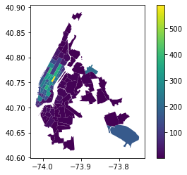

```python
pandas_pickups2015.plot("n_pickups", legend=True);
```

```python
pickups2018 = limit10K_2018.groupBy('PUzone').agg(fn.count('VendorID').alias('n_pickups')).toPandas()
```

```python
pandas_pickups2018 = locations.rename(columns={"zone": "PUzone"}).merge(pickups2018, on='PUzone')
```

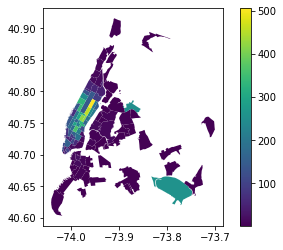

```python
pandas_pickups2018.plot("n_pickups", legend=True);
```

```python
# some zones are missing due to limit(10000)
```

[figure not shown]

```python
from IPython import display
display.Image("heatmap.png")
```

```python
# this heatmap comes from this code

# import pandas as pd
# import numpy as np
# import time

# import folium
# from folium.plugins import HeatMap
# from IPython.display import IFrame

# import calendar
# import os
# import time
# from selenium import webdriver
# from PIL import Image
# import glob

# limit10K_2015 = limit10K_2015.toPandas()


# # Function to visualize map
# def embed_map(map, filename):
#     map.save(filename)
#     return IFrame(filename, width='100%', height='500px')

# for j in range(0,24):
# #for i in range(limit10K_2015.weekday.min(), limit10K_2015.weekday.max()+1):
# #    for j in range(limit10K_2015.hour_of_day.min(), limit10K_2015.hour_of_day.max()+1):

#         # Filter to include only data for each day of week and hour of day
#         df_geo = limit10K_2015.loc[limit10K_2015.hour==j][['pickup_latitude', 'pickup_longitude']].copy()

#         # Instantiate map object
#         map_5 = folium.Map(location=[40.75, -73.96], tiles='openstreetmap', zoom_start=12)

#         # Plot heatmap
#         HeatMap(data=df_geo, radius=10).add_to(map_5)


#         # Add title to heatmap
#         title_html = f'''<h3 align="center" style="font-size:20px">
#                         <b>NYC Cab Pickups at {j}:00 on Thuesday: {len(df_geo)} rides</b></h3>
#                      '''
#         map_5.get_root().html.add_child(folium.Element(title_html))

#         # Save map
#         embed_map(map_5, f'./html_maps_pickup/Tue_{j}_heatmap.html')

# but we couldnt get it to work for all days/hours :()
```

```python
spark.stop()
```